# BO-NLME_Tutorial

Jim Hughes

2026-01-18

# Set up

```r
# Clear working directory
  rm(list = ls(all = TRUE))

# Load package libraries
  library(conflicted)
  library(tidyverse)
  library(grid)
  library(gridExtra)
  library(GGally)
  library(scales)

# Handle package conflicts
  conflict_scout()
  conflicts_prefer(dplyr::filter, dplyr::lag, purrr::discard,
    readr::col_factor, gridExtra::combine)

# Source custom functions
  source("var_labels.R")
  source("model_summary.R")
  source("plot_diagnostics.R")
  source("plot_vpc.R")

# Set directory paths
  dat_dir <- "../data"
  scr_dir <- "../scripts"
  mod_dir <- "../models"
  out_dir <- "../output"

# Set ggplot2 theme
  theme_bw2 <- theme_set(theme_bw(base_size = 12))
  theme_update(plot.margin = unit(c(1, 1.5, 1, 1), "lines"))
```

# Data

The dataset used for this vignette comes from the clinical trial described below. Only the data from the control arm is included in the dataset.

- https://clinicaltrials.gov/study/NCT00081796?tab=table
- https://www.sanofi.com/assets/dotcom/content-app/clinical-studies/pharma/Letter-L/EFC6089_summary.pdf

```r
# Load raw data
  raw_path <- file.path(dat_dir, "EQLQ_Clean_2004_23JUN2025.csv")
  raw_data <- read_csv(raw_path, col_types = cols(
    .default = col_double(),
    UID = col_character(),
    NCT = col_character(),
    QSFLAG = col_character(),
    SEX = col_character(),
    MENOS = col_character(),
    ECOG = col_character(),
    CHEMO = col_character(),
    SURGERY = col_character(),
    RADIO = col_character(),
    ERS = col_character(),
    PGRS = col_character(),
    MHDEPRESSION = col_character(),
    MDANXIETY = col_character()
  ))

# Define covariate types
  yesno_covs <- c("CHEMO", "SURGERY", "RADIO", "MHDEP", "MDANX")
  posneg_covs <- c("ERS", "PGRS")
  cat_covs <- c("STDID", "SEX", "RACE", "MENOS", "ECOG", "DTH", yesno_covs, posneg_covs)
  cont_covs <- c("AGE", "LESION1", "HEIGHT", "WEIGHT", "DTHDY", "PFSDY")
```

The raw data has a mix of integers and character strings describing different aspects of the study. This is cleaned up prior to preparing the data for anlaysis.

```r
# Prepare analysis dataset
  clean_data <- raw_data %>%
    rename(TAFD = TIME, MHDEP = MHDEPRESSION, MDANX = MDANXIETY) %>%
  # Map items to their respective scales
    left_join(unnest(qs_scales, FLAG), by = "FLAG") %>%
  # Convert categorical covariates to number format
    mutate(SEX = as.integer(factor(SEX, levels = c("Male", "Female")))) %>%
    mutate(MENOS = as.integer(factor(MENOS,
      levels = c("premenopausal", "other")))) %>%
    mutate(ECOG = as.integer(factor(ECOG, levels = c("0", "1", "3-Feb"))) - 1L) %>%
    mutate(across(all_of(yesno_covs), \(x) if_else(x == "Y", 1, 0))) %>%
    mutate(across(all_of(posneg_covs), \(x) if_else(x == "Positive", 1, 0))) %>%
    mutate(DTH = na_if(DTH, -999))
```

For bounded outcomes analysis you will be working with aggregate scores, but how you put those scores together depends on what approach you want to use. For this example the QLQ-C30 scores are calculated for visualization and presentation, along with a simple sum of scores which will be used for analysis as it can be used for both continuous and discrete bounded outcomes methods.

```r
  score_data <- clean_data %>%
  # Set flag to determine which scores require imputation
    group_by(across(all_of(c("ID", "TAFD", "TAFR", "SCALE",
      cat_covs, cont_covs)))) %>%
    mutate(IMPFL = length(DV) != n_items) %>%
  # Calculate scores
    summarise(
      raw_score = mean(DV),  # missing items imputed if at least 1 item remains
      score = if_else(unique(is_func),
        true = 100*(1 - (raw_score - 1)/unique(range)),  # Functioning
        false = 100*(raw_score - 1)/unique(range)  # Global Health + Symptom
      ),
      sum_score = sum(DV),
      raw_score_noimp = if_else(unique(IMPFL), NA_real_, raw_score),
      score_noimp = if_else(unique(IMPFL), NA_real_, score),
      sum_score_noimp = if_else(unique(IMPFL), NA_real_, sum_score),
      NQS = length(unique(FLAG)),
      .groups = "drop"
    ) %>%
  # Convert to long format and convert to numeric flag
    pivot_longer(contains("score"), names_to = "FLAG", values_to = "DV") %>%
    mutate(FLAG = as.integer(factor(FLAG,
      levels = c("raw_score", "score", "raw_score_noimp",
        "score_noimp", "sum_score", "sum_score_noimp")
    ))) %>%
    mutate(C = NA_real_, .before = 1)
```

## Explore data

Exploration of data prior to analysis is just as important for bounded outcomes analysis as other NLME anlayses. Typical visualizations used for exploring categorical or continuous data can be used.

For this vignette, the focus will be on the Physical Functioning domain of the questionnaire, due to it having a sufficient range of values to justify the use of beta regression (n = 16).

A key exploratory plot to explore is the distribution of the dependent variable. This can help determine whether the chosen method needs to handle values on the boundary or not. Below simple summarisation and histograms are used to explore the distribution, and identify that the data has a reverse J-shaped distribution, with many values at the lower boundary and some values at the upper boundary.

```r
  plot_data <- score_data %>%
    filter(FLAG == 1 & SCALE == 2) %>%
    left_join(select(qs_scales, SCALE, label), by = "SCALE") %>%
    mutate(label = factor(label, levels = qs_scales$label)) %>%
    reduce2(.init = ., catcov_labels, cat_covs, \(init, cat, cov) {
      left_join(init, cat, by = cov)
    }) %>%
    mutate(CFB = DV - first(DV), .by = "ID")
  count(plot_data, lower_bound = DV == 1, upper_bound = DV == 4)
```

```
## # A tibble: 3 × 3
##   lower_bound upper_bound     n
##   <lgl>       <lgl>       <int>
## 1 FALSE       FALSE        1037
## 2 FALSE       TRUE            4
## 3 TRUE        FALSE         226
```

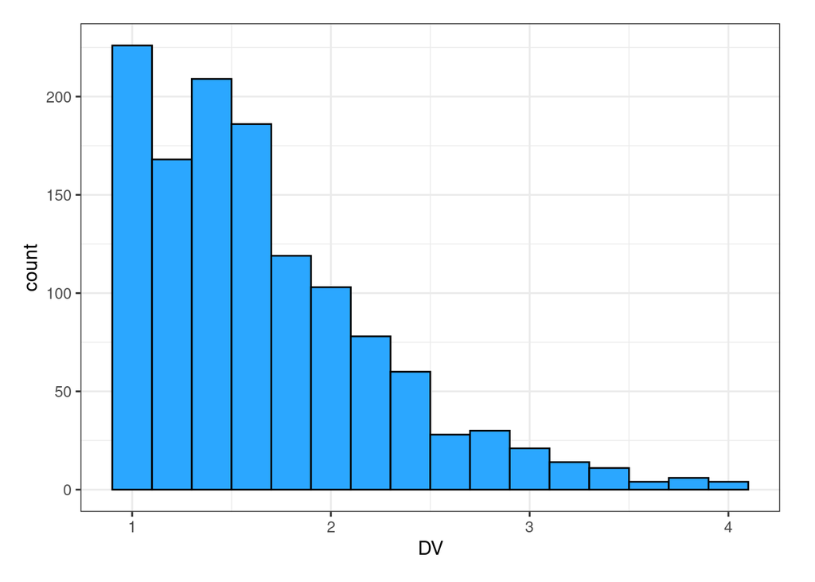

```r
  p <- ggplot(data = plot_data)
  p <- p + geom_histogram(aes(x = DV), bins = 16,
    fill = "#2BA7FF", colour = "black")
  p
```

Simple individual plots are shown as another example, to help visualize the types of PRO trajectories the final model will need to describe. The data has varied profiles, with an overall indication that a reasonable starting point for model development is a structural model that can describe some kind of placebo/standard of care effect along with disease progression.

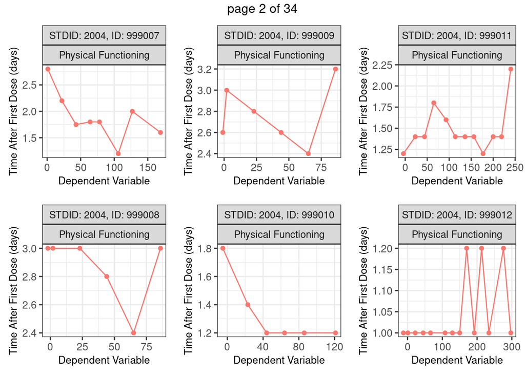

```r
  id_data <- plot_data %>%
    mutate(UID = paste0("STDID: ", STDID, ", ID: ", ID))
  unique_id <- unique(id_data$UID)
  unique_flag <- unique(id_data$label)
  id_plots <- map(unique_id, \(id) {
    plot_data <- filter(id_data, UID == id & FLAG == 1)
    pal_index <- which(unique_flag %in% unique(plot_data$label))
    p <- ggplot(data = plot_data)
    p <- p + geom_point(aes(x = TAFD, y = DV, colour = label))
    p <- p + geom_line(aes(x = TAFD, y = DV, colour = label))
    p <- p + labs(x = "Dependent Variable", y = "Time After First Dose (days)")
    p <- p + facet_wrap(c("UID", "label"), scales = "free", ncol = 3)
    p <- p + scale_shape_manual("Prediction", values = c(1, 2))
    p <- p + scale_linetype_manual("Prediction", values = c("solid","dashed"))
    p <- p + theme(legend.position = "none",
      plot.margin = unit(c(0.3, 0.3, 0.3, 0.3), "cm"),
      axis.title.x = element_text(size = 10),
      axis.text.x = element_text(size = 10),
      axis.title.y = element_text(size = 10),
      axis.text.y = element_text(size = 10)
    )
  })
  plot_grid <- marrangeGrob(grobs = id_plots, ncol = 3, nrow = 2,
    npages = ceiling(length(id_plots)/6))
  grid.draw(plot_grid[[2]])
```

# Model Definition

## Zero-/One-inflated Beta Regression

$$y=\frac{DV-DV_{lo}}{DV_{up}-DV_{lo}}$$

where $DV$ represents the raw integer score, while $DV_{lo}$ and $DV_{hi}$ represent the lower and upper boundary of the raw sum of scores respectively.

The main difference between beta regression and traditional PK/PD modelling is the assumption of the dependent variable being produced from a beta distribution rather than a normal distribution. Therefore the regression only differs in the residuals, with the probability that the value $y$ is observed being described by:

$$p(y)=Beta(\alpha,\beta) \\
p(y)=\frac{\Gamma(\alpha+\beta)}{\Gamma(\alpha)\Gamma(\beta)}y^{\alpha-1}(1-y)^{\beta-1}$$

where $\alpha$ and $\beta$ are shape parameters for the beta distribution and $y$ is constrained between 0 and 1.

A more convenient parameterization of the beta regression is to consider it in terms of the mean and variance of the distribution, such that:

$$E[Y]=\mu \\
Var[Y]=\frac{\mu(1-\mu)}{\phi+1} \\ \alpha=\mu\phi \\ \beta=(1-\mu)\phi$$

where $\mu$ is the mean prediction (constrained between 0 and 1) and $\phi$ is free to control the residuals (similar to $\sigma$ for a normal distribution.

To handle observations at the boundary, an inflated beta distribution is necessary such that:

$$p(y) = \begin{cases} p_0 & \text{if
}y=0 \\ p_1 & \text{if }y=1 \\ Beta(\alpha,\beta)(1-p_0-p_1) &
\text{otherwise} \end{cases} \\
p_0=\text{logit}^{-1}(-\zeta_1-\zeta_2\cdot\text{logit}(\mu))\\
p_1=\text{logit}^{-1}(-\zeta_1+\zeta_2\cdot\text{logit}(\mu))$$

where the inflation terms $p_0$ and $p_1$ are defined by a pair of functions with some decent properties, but most importantly that force the condition $p_0+p_1\le1$.

The remainder of the model remains largely the same as a typical PK/PD or exposure response model, ensuring that the resulting prediction can be transformed to produce a value constrained between 0 and 1.

$$\text{logit}(\mu)=BASE+P_{eff}+D_{prog}$$

where $IPRED$ is equal to baseline, $BASE$, plus placebo effect, $P_{eff}$, and disease progression, $D_{prog}$, and can take values from $-\infty$ to $\infty$.

## Discretized Beta Regression

Rather than using the beta probabiliity density function to determine the probability of observation $y$, instead discretized beta regression uses the cumulative distribution function. It does this by splitting the beta distribution up into $n$ segments, determining the probability of being between $y_{lo}$ and $y_{up}$.

$$y_{lo}=\frac{DV-DV_{lo}}{DV_{up}-DV_{lo}+1}\\
y_{up}=\frac{DV-DV_{lo}+1}{DV_{up}-DV_{lo}+1}\\ p(y)=P(y_{lo}<Y\le
y_{hi})=I_{y_{hi}}(\alpha,\beta)-I_{y_{lo}}(\alpha,\beta)$$

where $y_{lo}$ and $y_{hi}$ represent the breakpoints between all possible values of $y$, and $I_y$ is the cumulative distribution function for a beta distribution.

Many aspects of beta regression apply to discretized beta regression, including the ability to parameterize as either $\alpha$ & $\beta$ or $\mu$ & $\phi$, and ability to use standard structural models. The main difference and a potential advantage of discretized beta regression is that presence of observations on the boundary do not necessitate zero-/one-inflation, as the lowest and highest segments represent the boundaries.

# Model Runs and Diagnostics

For this vignette, two initial models are presented as a starting point. As with all non-linear mixed effects analysis, model development is an iterative process guided by an overall goal. These models are reasonable for producing EBEs representing PRO trajectories for use as predictors for other outcomes, but further work would be necessary to produce models with the goal of prediction.

Two models are provided in this vignette, the first “run7” analyzes the PRO data as a continuous bounded outcome using beta regression. The second analysis “run9” analyzes the PRO data as a discrete bounded outcome using discretized-beta regression. It should be noted that the objective function values between these two methods are not directly comparable, with inflated beta regression treating the data as continuous and using densities to calculate the likelihood, while discretized beta regression treats the data as discrete and uses probabilities to calculate the likelihood.

## Zero-/One-inflated Beta Regression

```r
  run7_path <- file.path(mod_dir, "run7")
  run7_summary <- model_summary(path = run7_path, param_labels = TRUE)
  run7_summary$ObjectiveFunctionValue
```

```
## # A tibble: 1 × 3
##     OFV   AIC   BIC
##   <dbl> <dbl> <dbl>
## 1 -757. -741. -700.
```

```r
  run7_summary$ConditionNumber
```

```
## [1] 25.03722
```

```r
  run7_summary$Theta
```

```
##   Number  Name      Value              RSE
## 1 THETA1  BASE  1.6642100 5.57513775304799
## 2 THETA2  PMAX -0.0765335 427.382780089765
## 3 THETA3  KPBO  0.0066378 189.449817710687
## 4 THETA4   PHI 16.9488000 11.2550151043142
## 5 THETA5 ZETA1  9.1851700 12.8450534938384
## 6 THETA6 ZETA2  4.0494100 14.9459797847094
```

```r
  run7_summary$Omega
```

```
##       Number    Name    Value       SD              RSE Shrinkage
## 1 OMEGA(1,1) IIVBASE 0.807353 0.898528 15.9641445563465   6.62885
## 2 OMEGA(2,2) IIVPMAX 1.261590 1.123210 211.139910747549  30.91230
```

For diagnostics individual predictions, population predictions and residuals are needed. These are all relatively simple to calculate for an inflated beta regression and are included as part of the control stream.

This vignette looks at goodness of fit and individual plots, but all standard NLME diagnostics can be applied here.

```r
# Read in subject-level data
  run7_eta <- file.path(run7_path, "run7.eta") %>%
    read_table(na = c("NA", "***********", "1.#INFE+00"), skip = 1,
      col_types = cols(.default = col_double()))
# Read in observation-level data
  run7_fit <- file.path(run7_path, "run7.fit") %>%
    read_table(na = c("NA", "***********", "1.#INFE+00"), skip = 1,
      col_types = cols(.default = col_double())) %>%
    left_join(run7_eta, by = "ID") %>%  # Add subject level data
    mutate(PROJ = "PF2") %>%
  # Add in categorical covariate information
    reduce2(.init = ., catcov_labels, cat_covs, \(init, cat, cov) {
      left_join(init, cat, by = cov)
    })
```

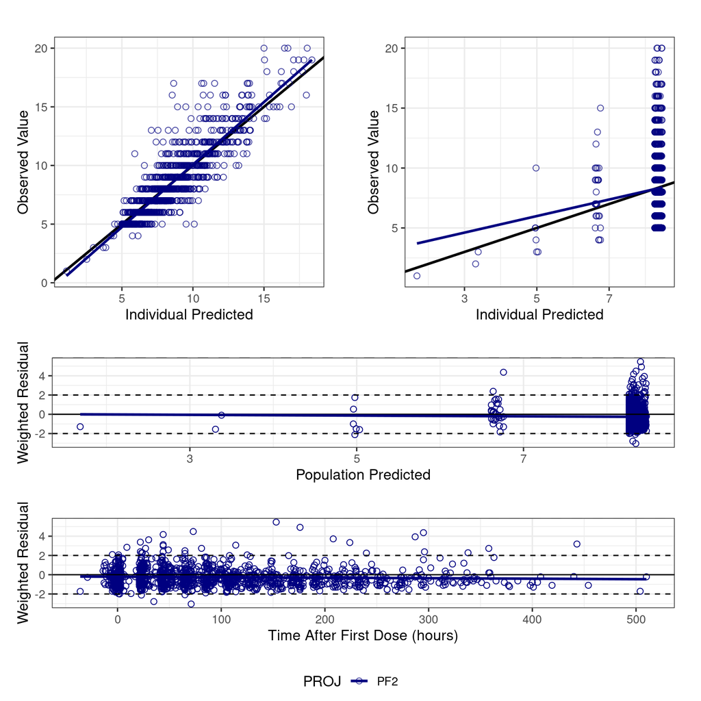

```r
# Create goodness of fit plots
  ipred_dv_plot <- obs_gof_plot(run7_fit,
    pred_name = "IPRED",
    dv_name = "DV",
    cov_name = "PROJ",
    pred_label = "Individual Predicted")
  pred_dv_plot <- obs_gof_plot(run7_fit,
    pred_name = "PPRED",
    dv_name = "DV",
    cov_name = "PROJ",
    pred_label = "Individual Predicted")
  wres_pred_plot <- res_gof_plot(run7_fit,
    res_name = "PWRES",
    x_name = "PPRED",
    cov_name = "PROJ",
    x_label = "Population Predicted",
    res_label = "Weighted Residual")
  wres_time_plot <- res_gof_plot(run7_fit,
    res_name = "PWRES",
    x_name = "TAFD",
    cov_name = "PROJ",
    units = "hours",
    x_label = "Time After First Dose",
    res_label = "Weighted Residual")
# Render plot
  combine_gof_plot(ipred_dv_plot, pred_dv_plot,
    wres_pred_plot, wres_time_plot)
```

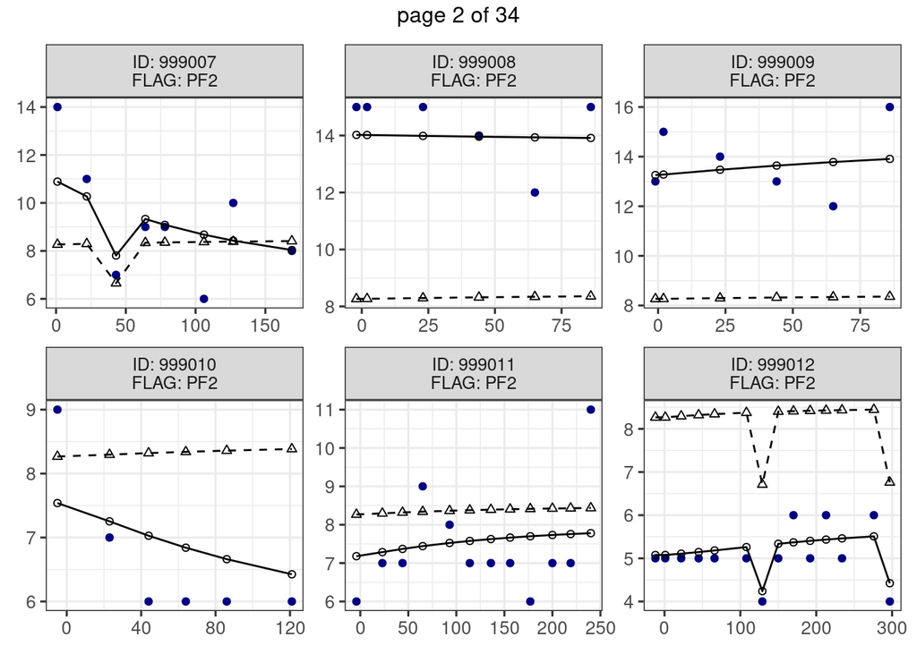

```r
# Create individual plots
  run7_id_data <- mutate(run7_fit, SID = paste0("ID: ", ID))
  p <- individual_plots(run7_id_data,
    dv_name = "DV",
    ipred_name = "IPRED",
    pred_name = "PPRED",
    time_name = "TAFD",
    id_name = "SID",
    flag_name = "PROJ",
    plots_per_page = 6
  )
  grid.draw(p[[2]])
```

Simulations can be performed in R for a simple model such as this. However, this vignette will be using NONMEM, with simulation code provided in `models/run7/sim7.mod`. `.fit` and `.eta` files have been pre-processed and saved to binary file to reduce size of vignette material.

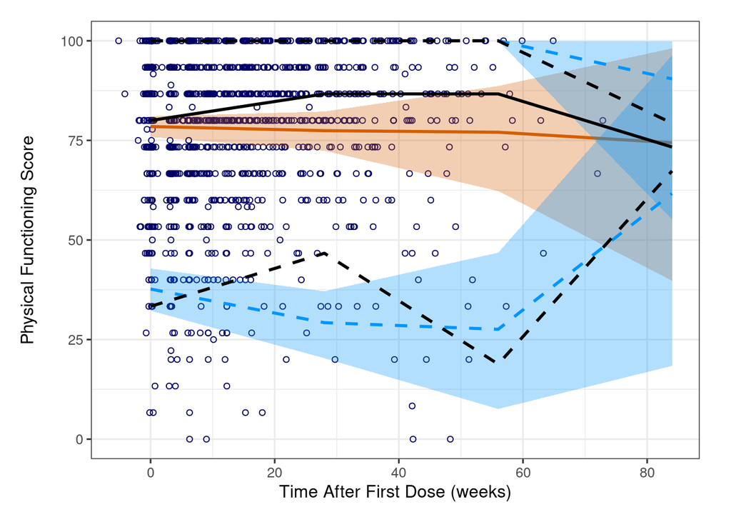

```r
# Prepare data for visual predictive check
  obs_data <- score_data %>%
    filter(SCALE == 2 & FLAG == 5) %>%
    mutate(PROJ = "PF2") %>%
    mutate(DV = 100*(1 - (DV/NQS - 1)/3))  # convert to score
  # run7_simeta <- file.path(run7_path, "sim7.eta") %>%
  #   read_table(na = c("NA", "***********", "1.#INFE+00"), skip = 1,
  #     col_types = cols(.default = col_double()))
  # run7_sim <- file.path(run7_path, "sim7.fit") %>%
  #   read_table(na = c("NA", "***********", "1.#INFE+00"), skip = 1,
  #     col_types = cols(.default = col_double())) %>%
  #   left_join(run7_eta, by = "ID") %>%  # Add subject level data
  #   filter(!is.na(SIM)) %>%
  #   mutate(PROJ = "PF2") %>%
  #   reduce2(.init = ., catcov_labels, cat_covs, \(init, cat, cov) {
  #     left_join(init, cat, by = cov)
  #   })
  # saveRDS(run7_sim, file.path(mod_dir, "run7", "sim7.rds"))
  run7_sim <- readRDS(file.path(mod_dir, "run7", "sim7.rds")) %>%
    mutate(PROJ = "PF2") %>%
    mutate(DV = 100*(1 - (DV/NQS - 1)/3))  # convert to score
  vpc_data <- list(obs = obs_data, sim = run7_sim) %>%
    map(mutate, WAFD = TAFD / 7)

# Define VPC bins
  tafd_labels <- c(0, 4, 8, 12, 16, 24, 40, 56)*7
  tafd_breaks <- c(-Inf, head(tafd_labels, -1) + diff(tafd_labels) / 2, Inf)
# Bin data for VPC
  tadbin_data <- vpc_data %>%
    map(bin_times,
      time_var = "WAFD",
      breaks = tafd_breaks,
      labels = tafd_labels
    )

# Summarise and plot VPC for percent change from baseline
  vpc_summary <- tadbin_data %>%
    map(summarise_vpc,
      time_var = "TIMEBIN",
      facet_cov = "PROJ")
  plot_vpc(
    obs_summary = vpc_summary$obs,
    sim_summary = vpc_summary$sim,
    obs_data = tadbin_data$obs,
    time_var = "WAFD",
    time_label = "Time After First Dose (weeks)",
    dv_label = "Physical Functioning Score\n",
    png_name = "VPC_run7"
  )
```

## Discretized Beta Regression

Similar to the inflated beta regression example, the model code in `models/run9/run9.mod` uses the in-built beta CDF function for efficiency. For this model the disease progression component was able to be included with successful minimization. It is possible this is due to the more parsimonious form of discretized beta regression.

```r
  run9_path <- file.path(mod_dir, "run9")
  run9_summary <- model_summary(path = run9_path, param_labels = TRUE)
  run9_summary$ObjectiveFunctionValue
```

```
## # A tibble: 1 × 3
##     OFV   AIC   BIC
##   <dbl> <dbl> <dbl>
## 1 4755. 4771. 4812.
```

```r
  run9_summary$ConditionNumber
```

```
## [1] 8.271227
```

```r
  run9_summary$Theta
```

```
##   Number Name       Value              RSE
## 1 THETA1 BASE  1.67200000 2.52271531100479
## 2 THETA2 PMAX  0.37988900 38.1835220288032
## 3 THETA3 KPBO  0.00759300   42.46858949032
## 4 THETA4 KDIS  0.00034216 72.3527004909984
## 5 THETA5  PHI 20.12120000 11.1003319881518
```

```r
  run9_summary$Omega
```

```
##       Number    Name    Value       SD              RSE Shrinkage
## 1 OMEGA(1,1) IIVBASE 0.967256 0.983492 14.9480592521525   7.00293
## 2 OMEGA(2,2) IIVPMAX 1.051520 1.025440 48.9265063907486  38.34970
## 3 OMEGA(3,3) IIVKDIS 3.449360 1.857250 37.1692139991187  51.54950
```

Again, individual predictions, population predictions and residuals are needed. This is a little more difficult with discretized beta regression, so in this example they are calculated outside of NONMEM.

```r
# Read in subject-level data
  run9_eta <- file.path(run9_path, "run9.eta") %>%
    read_table(na = c("NA", "***********", "1.#INFE+00"), skip = 1,
      col_types = cols(.default = col_double()))
# Read in observation-level data
  run9_fit <- file.path(run9_path, "run9.fit") %>%
    read_table(na = c("NA", "***********", "1.#INFE+00"), skip = 1,
      col_types = cols(.default = col_double())) %>%
    left_join(run9_eta, by = "ID") %>%  # Add subject level data
    mutate(PROJ = "PF2") %>%
  # Add in categorical covariate information
    reduce2(.init = ., catcov_labels, cat_covs, \(init, cat, cov) {
      left_join(init, cat, by = cov)
    }) %>%
  # Calculate predictions (i.e. expectation) and residuals
  # Requires determining the probability of each possible value y can take
  # Population predictions
    mutate(PRED = pmap_dbl(list(PMU, DVLO, DVUP, PHI),
      .f = \(PMU, DVLO, DVUP, PHI) {
        reduce(.init = 0, seq(DVLO, DVUP), \(init, x) {
          xlo <- (x - DVLO)/(DVUP - DVLO + 1)
          xup <- (x - DVLO + 1)/(DVUP - DVLO + 1)
          cdflo <- pbeta(xlo, PMU*PHI, (1 - PMU)*PHI)
          cdfup <- pbeta(xup, PMU*PHI, (1 - PMU)*PHI)
          init + x*(cdfup - cdflo)
        })
      }
    )) %>%
  # Individual predictions and Pearson standard deviation
    mutate(tmp = pmap(list(MU, DVLO, DVUP, PHI),
      .f = \(MU, DVLO, DVUP, PHI) {
        pmf <- map(seq(DVLO, DVUP), \(x) {
          xlo <- (x - DVLO)/(DVUP - DVLO + 1)
          xup <- (x - DVLO + 1)/(DVUP - DVLO + 1)
          cdflo = pbeta(xlo, MU*PHI, (1 - MU)*PHI)
          cdfup = pbeta(xup, MU*PHI, (1 - MU)*PHI)
          list(x = x, p = cdfup - cdflo)
        })
        tibble(IPRED = 0, PSD = 0) %>%
          reduce(.init = ., .x = pmf, .f = \(init, pmf) {
            mutate(init, IPRED = IPRED + pmf$p*pmf$x)
          }) %>%
          reduce(.init = ., .x = pmf, .f = \(init, pmf) {
            mutate(init, PSD = PSD + pmf$p*(pmf$x - IPRED)^2)
          }) %>%
          mutate(PSD = sqrt(PSD))
      }
    )) %>%
    unnest(tmp) %>%
  # Pearson weighted residuals
    mutate(PWRES = (DV - IPRED)/PSD)
```

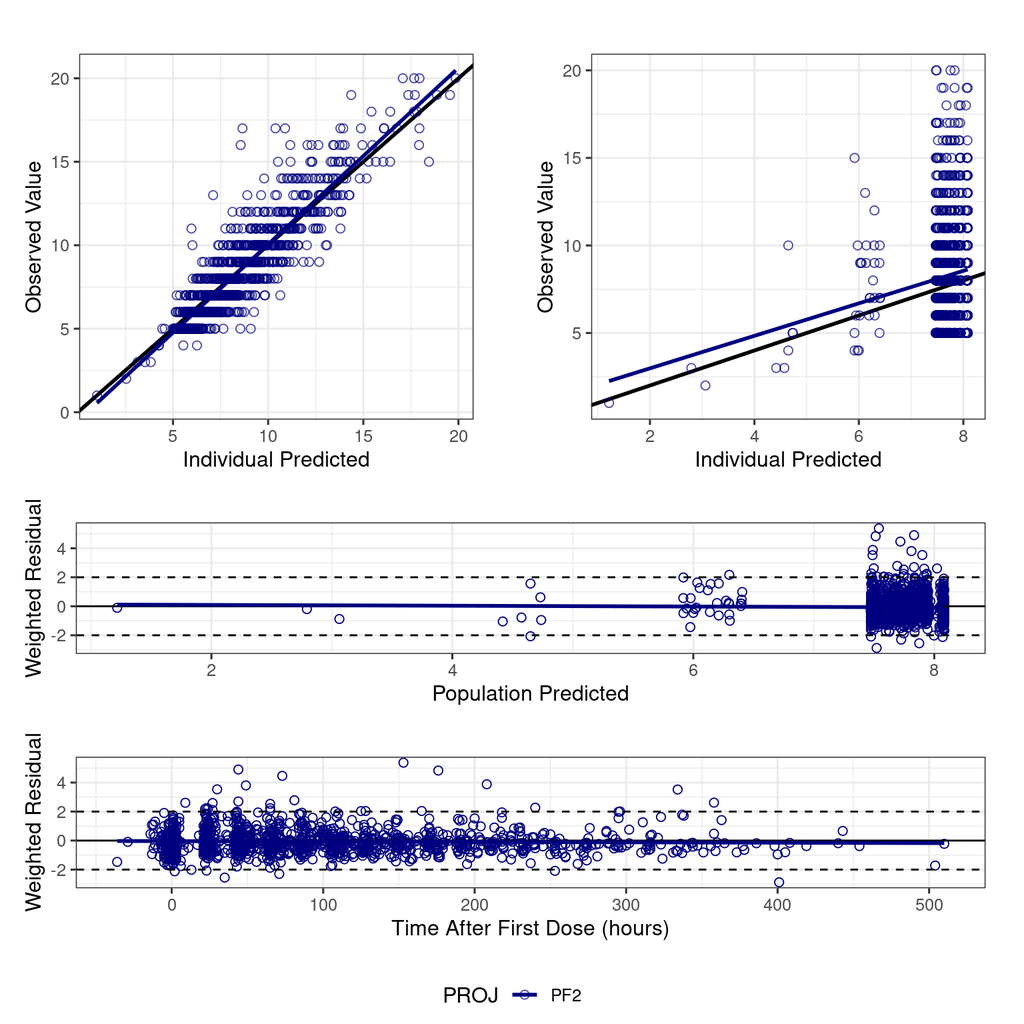

```r
# Create goodness of fit plots
  ipred_dv_plot <- obs_gof_plot(run9_fit,
    pred_name = "IPRED",
    dv_name = "DV",
    cov_name = "PROJ",
    pred_label = "Individual Predicted")
  pred_dv_plot <- obs_gof_plot(run9_fit,
    pred_name = "PRED",
    dv_name = "DV",
    cov_name = "PROJ",
    pred_label = "Individual Predicted")
  wres_pred_plot <- res_gof_plot(run9_fit,
    res_name = "PWRES",
    x_name = "PRED",
    cov_name = "PROJ",
    x_label = "Population Predicted",
    res_label = "Weighted Residual")
  wres_time_plot <- res_gof_plot(run9_fit,
    res_name = "PWRES",
    x_name = "TAFD",
    cov_name = "PROJ",
    units = "hours",
    x_label = "Time After First Dose",
    res_label = "Weighted Residual")
# Render plot
  combine_gof_plot(ipred_dv_plot, pred_dv_plot,
    wres_pred_plot, wres_time_plot)
```

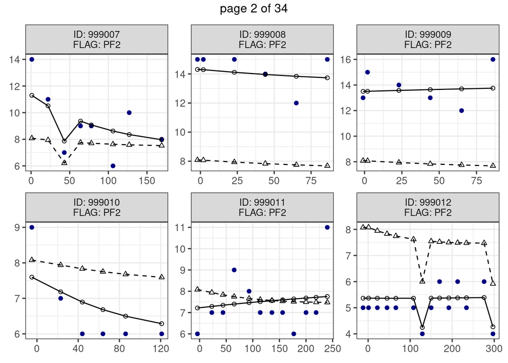

```r
# Create individual plots
  run9_id_data <- mutate(run9_fit, SID = paste0("ID: ", ID))
  p <- individual_plots(run9_id_data,
    dv_name = "DV",
    ipred_name = "IPRED",
    pred_name = "PRED",
    time_name = "TAFD",
    id_name = "SID",
    flag_name = "PROJ",
    plots_per_page = 6
  )
  grid.draw(p[[2]])
```

Again, this model could be entirely simulated in R, but an example using NONMEM is provided. Conducting simulations completely in NONMEM is more difficult for discretized beta regression. Therefore, NONMEM will be used to simulate the structural model (often desirable for more computationally challenging models containing differential equations), and R will be used to simulate from the discretized beta distribution. Simulation code is provided in `models/run9/sim9.mod`. Again, `.fit` and `.eta` files are pre-processed here to save on space, but also due to long runtime.

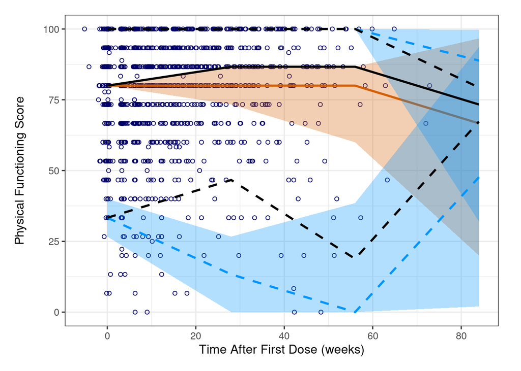

```r
# Simulate using NONMEM structural model simulations
  # set.seed(555)
  # future::plan(future::multisession, workers = length(future::availableWorkers()) - 1)
  # run9_simeta <- file.path(run9_path, "sim9.eta") %>%
  #   read_table(na = c("NA", "***********", "1.#INFE+00"), skip = 1,
  #     col_types = cols(.default = col_double()))
  # run9_sim <- file.path(run9_path, "sim9.fit") %>%
  #   read_table(na = c("NA", "***********", "1.#INFE+00"), skip = 1,
  #     col_types = cols(.default = col_double())) %>%
  #   left_join(run9_eta, by = "ID") %>%  # Add subject level data
  #   filter(!is.na(SIM)) %>%
  #   mutate(PROJ = "PF2") %>%
  #   rename(MU = DV) %>%
  #   reduce2(.init = ., catcov_labels, cat_covs, \(init, cat, cov) {
  #     left_join(init, cat, by = cov)
  #   }) %>%
  #   mutate(DV = furrr::future_pmap_dbl(list(MU, PHI, DVLO, DVUP),
  #     .f = \(MU, PHI, DVLO, DVUP) {
  #       pmf <- accumulate(seq(DVLO, DVUP), .init = tibble(x = -99, p = 0), \(init, x) {
  #         xlo <- (x - DVLO)/(DVUP - DVLO + 1)
  #         xup <- (x - DVLO + 1)/(DVUP - DVLO + 1)
  #         cdflo = pbeta(xlo, MU*PHI, (1 - MU)*PHI)
  #         cdfup = pbeta(xup, MU*PHI, (1 - MU)*PHI)
  #         tibble(x = x, p = init$p + (cdfup - cdflo))
  #       })
  #       pmf %>%
  #         filter(runif(1) <= p) %>%
  #         head(1) %>%
  #         pull(x)
  #     }, .progress = TRUE, .options = furrr::furrr_options(seed = TRUE)
  #   ))
  # saveRDS(run9_sim, file.path(mod_dir, "run9", "sim9.rds"))
  run9_sim <- readRDS(file.path(mod_dir, "run9", "sim9.rds")) %>%
    mutate(PROJ = "PF2") %>%
    mutate(DV = 100*(1 - (DV/NQS - 1)/3))  # convert to score
  vpc_data <- list(obs = obs_data, sim = run9_sim) %>%
    map(mutate, WAFD = TAFD / 7)

# Define VPC bins
  tafd_labels <- c(0, 4, 8, 12, 16, 24, 40, 56)*7
  tafd_breaks <- c(-Inf, head(tafd_labels, -1) + diff(tafd_labels) / 2, Inf)
# Bin data for VPC
  tadbin_data <- vpc_data %>%
    map(bin_times,
      time_var = "WAFD",
      breaks = tafd_breaks,
      labels = tafd_labels
    )

# Summarise and plot VPC for percent change from baseline
  vpc_summary <- tadbin_data %>%
    map(summarise_vpc,
      time_var = "TIMEBIN",
      facet_cov = "PROJ")
  plot_vpc(
    obs_summary = vpc_summary$obs,
    sim_summary = vpc_summary$sim,
    obs_data = tadbin_data$obs,
    time_var = "WAFD",
    time_label = "Time After First Dose (weeks)",
    dv_label = "Physical Functioning Score\n",
    png_name = "VPC_run9"
  )
```